# Prueba 2-Copy1

## Descripción

Yelp es un directorio de servicios a nivel mundial, que permite a sus usuarios el evaluar los servicios (restaurants, bancos, clínicas, gimnasios, entre otros) para encontrar y sugerir mejores servicios.

- Identificar usuarios molestosos.
- Probabilidad de cierre de los negocios.

Los datos se disponibilizaron en la página https://www.yelp.com/dataset/challenge.

Para efectos prácticos de la prueba:

- Los archivos disponibles se encuentran en el bucket del módulo, con la dirección `s3://bigdata-desafio/yelp-data/`.
- Dentro de esta dirección encontrará distintos archivos json con:
  - Registros respecto al negocio (`business.json`)
  - check-ins del usuario en un negocio (`checkin.json`)
  - Fotos asociadas al review (`photo.json`)
  - Reseñas de un usuario sobre el servicio (`review.json`)
  - Sugerencias del usuario sobre el servicio ( `tip.json` )
  - Información del usuario (`user.json` )

La definición de la estructura de datos de cada json se encuentra alojada en la siguiente dirección provista por Yelp: https://www.yelp.com/dataset/documentation/main. (Dentro de este link se encontrarán las definiciones de las columnas y el tipo de registro).

## Ejercicio 1: Identificando usuarios molestosos

Desde Yelp están interesados en identificar a aquellos usuarios que se pueden considerar como molestosos. Para ello, tienen la siguiente definición de un usuario molestoso:

1. Un usuario molestoso es aquél que su promedio de evaluaciones es menor o igual a 2.
2. Un usuario molestoso es aquel que tiene en promedio menos de 100 reviews.
3. Un usuario molestoso es aquél que tiene cero fans.

A partir de esta definición, se le solicita los siguientes puntos:

- Identifique en una variable dummy todos los usuarios que se puedan clasificar como molestosos acorde al criterio.
- Recodificaciones en el archivo `user.json`:
  - `friends`, que corresponde a un string con todos los user_id de otros usuarios que siguen al usuario. El objetivo es contar la cantidad de amigos existentes.
  - `elite`, que corresponde a un string con todos los años en los que el usuario fue considerado como un reviewer de elite. El objetivo es contar la cantidad de años en los cuales se consideró como elite.
  - Asegúrese de eliminar los siguientes registros: `friends`, `yelping_since`, `name`, `elite`, `user_id`.

```python
import pyspark
```

```
Starting Spark application
```

| ID | YARN Application ID | Kind | State | Spark UI | Driver log | Current session? |
| --- | --- | --- | --- | --- | --- | --- |
| 6 | application_1608254408313_0007 | pyspark | idle | [Link](http://ip-172-31-84-224.ec2.internal:20888/proxy/application_1608254408313_0007/) | [Link](http://ip-172-31-91-239.ec2.internal:8042/node/containerlogs/container_1608254408313_0007_01_000001/livy) | ✔ |

```
SparkSession available as 'spark'.
```

```python
users = spark.read.json('s3://bigdata-desafio/yelp-data/user.json')
users.printSchema()
```

```
root
 |-- average_stars: double (nullable = true)
 |-- compliment_cool: long (nullable = true)
 |-- compliment_cute: long (nullable = true)
 |-- compliment_funny: long (nullable = true)
 |-- compliment_hot: long (nullable = true)
 |-- compliment_list: long (nullable = true)
 |-- compliment_more: long (nullable = true)
 |-- compliment_note: long (nullable = true)
 |-- compliment_photos: long (nullable = true)
 |-- compliment_plain: long (nullable = true)
 |-- compliment_profile: long (nullable = true)
 |-- compliment_writer: long (nullable = true)
 |-- cool: long (nullable = true)
 |-- elite: string (nullable = true)
 |-- fans: long (nullable = true)
 |-- friends: string (nullable = true)
 |-- funny: long (nullable = true)
 |-- name: string (nullable = true)
 |-- review_count: long (nullable = true)
 |-- useful: long (nullable = true)
 |-- user_id: string (nullable = true)
 |-- yelping_since: string (nullable = true)
```

```python
users.show(1)
```

```
+-------------+---------------+---------------+----------------+--------------+---------------+---------------+---------------+-----------------+----------------+------------------+-----------------+----+--------------+----+--------------------+-----+------+------------+------+--------------------+-…
|average_stars|compliment_cool|compliment_cute|compliment_funny|compliment_hot|compliment_list|compliment_more|compliment_note|compliment_photos|compliment_plain|compliment_profile|compliment_writer|cool|         elite|fans|             friends|funny|  name|review_count|useful|             user_id| …
+-------------+---------------+---------------+----------------+--------------+---------------+---------------+---------------+-----------------+----------------+------------------+-----------------+----+--------------+----+--------------------+-----+------+------------+------+--------------------+-…
|         4.03|              1|              0|               1|             2|              0|              0|              1|                0|               1|                 0|                2|  25|2015,2016,2017|   5|c78V-rj8NQcQjOI8K...|   17|Rashmi|          95|    84|l6BmjZMeQD3rDxWUb...|2…
+-------------+---------------+---------------+----------------+--------------+---------------+---------------+---------------+-----------------+----------------+------------------+-----------------+----+--------------+----+--------------------+-----+------+------------+------+--------------------+-…
only showing top 1 row
```

```python
users.registerTempTable('users')

spark.sql('''select user_id,count(*)
               from users
               group by user_id
               order by count(*) desc limit 10''').show(10,False)
```

```
+----------------------+--------+
|user_id               |count(1)|
+----------------------+--------+
|NBQ_U_D158jCNnvf0Z9NIg|1       |
|UbLiuMRsJ-Whr_x-87Do7A|1       |
|FCSE5q7bQtBEWtDj8rA5oA|1       |
|Tjip511lNFMISUFRzkc7nA|1       |
|HveWFVvoMU4F-O7pWgrfXg|1       |
|nmi-N-Efoc_ED-K87uDa_Q|1       |
|SnaOPYktz-Y0oDRWjIErzA|1       |
|66U5fG7YFO1l3cjG6LEuQA|1       |
|68GMJd0dfq0WAh1HlRomCg|1       |
|DlR_aY7uI-4_0xZW0YKgYg|1       |
+----------------------+--------+
```

La tabla presenta registros únicos

```python
from pyspark.sql.functions import when, size, split, col, count, isnull
```

```python
users.select([count(when(isnull(c), c)).alias(c) for c in users.columns]).show()
```

```
+-------------+---------------+---------------+----------------+--------------+---------------+---------------+---------------+-----------------+----------------+------------------+-----------------+----+-----+----+-------+-----+----+------------+------+-------+-------------+
|average_stars|compliment_cool|compliment_cute|compliment_funny|compliment_hot|compliment_list|compliment_more|compliment_note|compliment_photos|compliment_plain|compliment_profile|compliment_writer|cool|elite|fans|friends|funny|name|review_count|useful|user_id|yelping_since|
+-------------+---------------+---------------+----------------+--------------+---------------+---------------+---------------+-----------------+----------------+------------------+-----------------+----+-----+----+-------+-----+----+------------+------+-------+-------------+
|            0|              0|              0|               0|             0|              0|              0|              0|                0|               0|                 0|                0|   0|    0|   0|      0|    0|   0|           0|     0|      0|            0|
+-------------+---------------+---------------+----------------+--------------+---------------+---------------+---------------+-----------------+----------------+------------------+-----------------+----+-----+----+-------+-----+----+------------+------+-------+-------------+
```

Se tiene que la data no presenta datos perdidos

### Identificación de usuario molesto

```python
users = users\
    .withColumn('molesto', when((users['average_stars'] <= 2) | (users['review_count'] < 100) | (users['fans'] == 0), 1)\
    .otherwise(0))
users.registerTempTable('users')
```

```python
spark.sql('''select user_id
                   ,average_stars
                   ,review_count
                   ,fans
                   ,molesto
             from users
             order by rand()''').show(30,False)
```

```
+----------------------+-------------+------------+----+-------+
|user_id               |average_stars|review_count|fans|molesto|
+----------------------+-------------+------------+----+-------+
|0cYyxgAg0dfQYRLx7qLA9Q|3.53         |14          |0   |1      |
|NqNffZ22PJLXtjChQ6I9NA|5.0          |1           |0   |1      |
|0vG46iMBV3GdjmQbAY0t1A|4.4          |10          |0   |1      |
|v-KtbA8RcUzfsrpXtr8IKQ|3.22         |99          |15  |1      |
|gQOjW_KyczrdApwVPPc3GQ|3.2          |9           |0   |1      |
|clL4OOqT9PlOsK5tvza1iQ|4.89         |9           |1   |1      |
|-2JaWozmY9C4s0l0qqMkTg|3.0          |2           |0   |1      |
|IBf3-iCBFrw53GLgySNVkA|3.67         |18          |0   |1      |
|x0KpuNo2mJpclVmme8OwCQ|3.96         |26          |0   |1      |
|ZBWFfWR4CD9_m-A3kmZJ3Q|3.0          |1           |0   |1      |
|9QwbF4J8ZP3Ztt2024DGjg|4.0          |2           |0   |1      |
|p2HWvXXM6PA7a-NV8jn9xw|3.4          |20          |0   |1      |
|uYRrXqJiOvhgfs1ZTEYiUQ|1.0          |1           |0   |1      |
|Jqgu0nJUyEWBh1jsaI25lA|3.4          |5           |0   |1      |
|XSCWBtC1i-TpAu_79fxZGw|2.08         |24          |0   |1      |
|1Ccd4u_7N-2KVpMHJ0dYAA|3.06         |10          |0   |1      |
|4NI-cVqqGop0wdhMrmVU7Q|3.82         |15          |1   |1      |
|abPbLMWrcQKAJUe8UYkn1w|2.7          |23          |0   |1      |
|LCsvOx95ITnuNFcFQdDSdg|4.0          |4           |0   |1      |
|eRlHT3ryMtMC2mah8oOQFg|5.0          |2           |0   |1      |
|QNypY-wfhY3rSo5sIcl0Fg|5.0          |2           |0   |1      |
|zH_aJ-ZZ1GWtsp4QYoiGUA|4.67         |3           |0   |1      |
|YBhkVIVtO5Qm1mytP-Lc4A|3.42         |17          |0   |1      |
|7XcAPvcI5z1WaDX6h7kNqg|3.72         |344         |1   |0      |
|OrrgcWX1ycpgibQeT9P5rA|3.88         |38          |0   |1      |
|0cOOaWvq61axZtsRhFp1kA|1.0          |2           |0   |1      |
|mRmJC3DS0SjCs73BFTSkXg|2.67         |8           |0   |1      |
|xl9IHjCIV9IMcKyxBC2Oug|3.29         |14          |1   |1      |
|ShmDxFOPf2IhLbY54-OVNA|4.22         |89          |14  |1      |
|Wu5sEg2CocgSjOXjuB3mpw|3.17         |6           |0   |1      |
+----------------------+-------------+------------+----+-------+
only showing top 30 rows
```

```python
spark.sql('''select molesto, count(*)
             from users
             group by molesto''').show(2,False)
```

```
+-------+--------+
|molesto|count(1)|
+-------+--------+
|1      |1566689 |
|0      |70449   |
+-------+--------+
```

Existe un fuerte desbalanceo de los datos, dado que el grupo de los que no se consideran usuarios molestos es de un 4,5% del universo de los que sí lo son.

### Recodificación de la variable friend_count

```python
users = users.withColumn('friend_count', size(split(col('friends'), ',')))
```

```python
users.registerTempTable('users')
```

```python
spark.sql('''select user_id,friend_count
             from users
             order by friend_count desc
             limit 10''').show(10,False)
```

```
+----------------------+------------+
|user_id               |friend_count|
+----------------------+------------+
|qVc8ODYU5SZjKXVBgXdI7w|14995       |
|iLjMdZi0Tm7DQxX1C1_2dg|12200       |
|ZIOCmdFaMIF56FR-nWr_2A|9564        |
|mV4lknblF-zOKSF8nlGqDA|9068        |
|IU86PZPgTDCFwJEuAg2j7g|8641        |
|F_5_UNX-wrAFCXuAkBZRDw|8586        |
|djxnI8Ux8ZYQJhiOQkrRhA|8381        |
|Oi1qbcz2m2SnwUeztGYcnQ|8297        |
|c-Dja5bexzEWBufNsHfRrQ|8182        |
|wEE-YMx5pmSuagLtNxMPKA|7906        |
+----------------------+------------+
```

Los 10 usuarios con más amigos

### Recodificación variable elite

```python
users = users.withColumn('elite_count',size(split(col('elite'), ',')))
```

```python
users.registerTempTable('users')
```

```python
spark.sql('''select user_id,elite_count
             from users
             order by elite_count desc
             limit 10''').show(10,False)
```

```
+----------------------+-----------+
|user_id               |elite_count|
+----------------------+-----------+
|5F_ASUSCHFf3YotkKioZ5w|13         |
|8h1r7mXd-H225yDgc4EMPg|13         |
|y-1YkRfAGhmYXvpu412H4A|13         |
|NIhcRW6DWvk1JQhDhXwgOQ|13         |
|LnZUtFx6qTWs8NV6lAARxQ|13         |
|cD_hpkvErXCyQHBQzv8KYQ|13         |
|Ffa1cXIvFAy8H1sorICaiQ|13         |
|UQFE3BT1rsIYrcDvu_XVow|13         |
|igaoaFNkX7ieMuyUBg0u5w|13         |
|gjRvBu1th-YobqPwPTysJQ|13         |
+----------------------+-----------+
```

Se observa que a lo más los usuarios han sido categorizados 13 años como reviewer de elite

### Eliminación de columnas

```python
columns_drop = ['friends', 'elite', 'yelping_since', 'user_id'
                , 'name','average_stars','review_count','fans']
users = users.drop(*columns_drop)
```

```python
users.registerTempTable('users')
```

### Visualización datos preprocesados

```python
%%sql -o users
SELECT * FROM users
```

```python
#%%local
#!pip3 install seaborn
```

```python
%%local
import numpy as np
import seaborn as sns
import matplotlib.pyplot as plt
import warnings
warnings.filterwarnings('ignore')
```

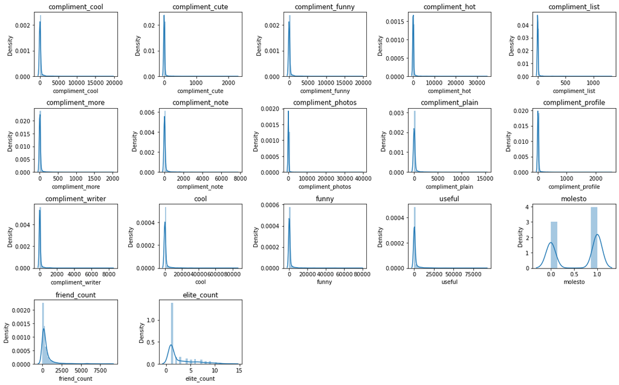

```python
%%local
rows = 4
cols = np.ceil(len(users.columns) / rows)
plt.rcParams['figure.figsize'] = (16, 10)
for index, (colname, serie) in enumerate(users.iteritems()):
    plt.subplot(rows, cols, index + 1)
    if serie.dtype == 'object':
        sns.countplot(serie);
    else:
        sns.distplot(serie)
    plt.title(colname);
    plt.tight_layout()
```

### Featuring enginering

```python
users = users.withColumnRenamed('molesto','label')
users.printSchema()
```

```
root
 |-- compliment_cool: long (nullable = true)
 |-- compliment_cute: long (nullable = true)
 |-- compliment_funny: long (nullable = true)
 |-- compliment_hot: long (nullable = true)
 |-- compliment_list: long (nullable = true)
 |-- compliment_more: long (nullable = true)
 |-- compliment_note: long (nullable = true)
 |-- compliment_photos: long (nullable = true)
 |-- compliment_plain: long (nullable = true)
 |-- compliment_profile: long (nullable = true)
 |-- compliment_writer: long (nullable = true)
 |-- cool: long (nullable = true)
 |-- funny: long (nullable = true)
 |-- useful: long (nullable = true)
 |-- label: integer (nullable = false)
 |-- friend_count: integer (nullable = false)
 |-- elite_count: integer (nullable = false)
```

```python
features = users.columns
features.remove('label')
```

```python
from pyspark.ml.feature import VectorAssembler
assemble_features = VectorAssembler(inputCols = features, outputCol = 'assembled_features')
assemble_features = assemble_features.transform(users)
assemble_features = assemble_features.select(['label', 'assembled_features'])
```

```python
assemble_features.show(5,False)
```

```
+-----+--------------------------------------------------------------------------------+
|label|assembled_features                                                              |
+-----+--------------------------------------------------------------------------------+
|1    |[1.0,0.0,1.0,2.0,0.0,0.0,1.0,0.0,1.0,0.0,2.0,25.0,17.0,84.0,99.0,3.0]           |
|1    |(16,[0,2,3,11,12,13,14,15],[1.0,1.0,1.0,16.0,22.0,48.0,1152.0,1.0])             |
|1    |(16,[6,11,12,13,14,15],[1.0,10.0,8.0,28.0,15.0,1.0])                            |
|1    |(16,[3,8,10,11,12,13,14,15],[1.0,2.0,1.0,14.0,4.0,30.0,525.0,1.0])              |
|0    |[80.0,0.0,80.0,28.0,1.0,1.0,16.0,5.0,57.0,0.0,25.0,665.0,279.0,1114.0,231.0,4.0]|
+-----+--------------------------------------------------------------------------------+
only showing top 5 rows
```

### Modelamiento

```python
train, test = assemble_features.randomSplit([0.7, 0.3], seed = 12334)
```

```python
from pyspark.ml.classification import LogisticRegression, GBTClassifier, DecisionTreeClassifier
from pyspark.ml.evaluation import BinaryClassificationEvaluator
```

#### Logistic Regression

```python
lrModel = LogisticRegression(featuresCol = 'assembled_features', labelCol = 'label', maxIter=10).fit(train)
predict_lr = lrModel.transform(test)
metric_lr = lrModel.evaluate(test).areaUnderROC
```

#### GBTClassifier

```python
GBT = GBTClassifier(featuresCol='assembled_features', labelCol='label').fit(train)
predict_GBT = GBT.transform(test)
evaluaGBT = BinaryClassificationEvaluator()
metric_GBT = evaluaGBT.evaluate(predict_GBT, {evaluaGBT.metricName : "areaUnderROC"})
```

#### DecisionTreeClassifier

```python
DTreeC = DecisionTreeClassifier(featuresCol='assembled_features', labelCol='label').fit(train)
predict_DTreeC = DTreeC.transform(test)
evaluaDT = BinaryClassificationEvaluator()
metric_DTreeC = evaluaDT.evaluate(predict_DTreeC, {evaluaDT.metricName : "areaUnderROC"})
```

```python
print('El AUC de LogisticRegression es {}.'.format(round(metric_lr,5)))
print('El AUC de GBTClassifier es {}.'.format(round(metric_GBT,5)))
print('El AUC de DecisionTreeClassifier es {}.'.format(round(metric_DTreeC,5)))
```

```
El AUC de LogisticRegression es 0.99241.
El AUC de GBTClassifier es 0.99314.
El AUC de DecisionTreeClassifier es 0.9427.
```

Dado un mejor desempeño del AUC en el modelo GBTClassifier, este debería ser el usado para predecir los usuarios molestosos.

### Principales atributos

```python
import pandas as pd
```

```python
feat_importance = pd.DataFrame({'col':features, 'importance': GBT.featureImportances.toArray()})
sdf = sqlContext.createDataFrame(feat_importance)
sdf.select("*").show()
```

```
+------------------+--------------------+
|               col|          importance|
+------------------+--------------------+
|   compliment_cool|0.004392376483947...|
|   compliment_cute|3.830017408407224E-4|
|  compliment_funny|                 0.0|
|    compliment_hot| 0.02521331811223973|
|   compliment_list|0.001886445277335...|
|   compliment_more|9.336754290060253E-4|
|   compliment_note|0.011913493518132184|
| compliment_photos|0.004440391251044359|
|  compliment_plain|0.008041488978046421|
|compliment_profile|0.007773240247771905|
| compliment_writer|0.016649917123319667|
|              cool|   0.399541492749644|
|             funny|0.017566751973073228|
|            useful| 0.43982986931537205|
|      friend_count|0.001816225007252...|
|       elite_count| 0.05961831279297334|
+------------------+--------------------+
```

```python
sdf.registerTempTable('features')
```

```python
%%sql -o features
SELECT col AS atribute, importance FROM features ORDER BY importance asc
```

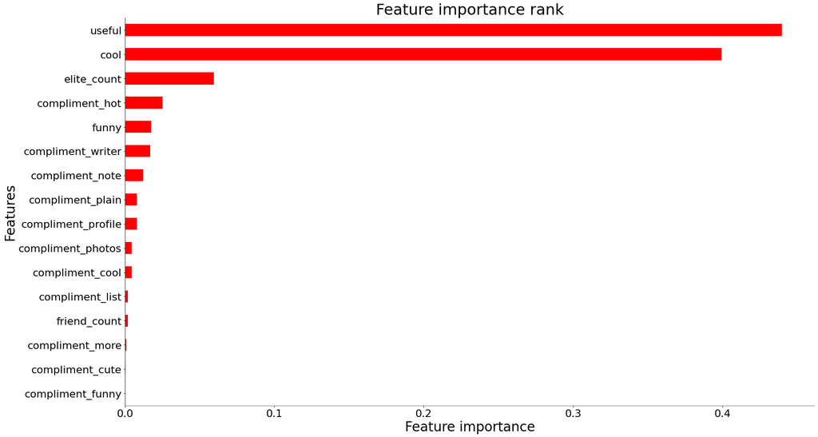

```python
%%local
ind = features.set_index("atribute", inplace = True)
barh = features.plot(kind='barh',figsize=(26, 15), color = "red", legend = None)
barh
plt.yticks(fontsize = 22)
plt.xticks(ind,fontsize = 22)
plt.xlabel("Feature importance", fontsize = 28)
plt.ylabel("Features", fontsize = 28)
plt.title("Feature importance rank", fontsize=32)
barh.spines['top'].set_visible(False)
barh.spines['right'].set_visible(False)
barh.spines['bottom'].set_linewidth(0.5)
barh.spines['left'].set_visible(True)
plt.show()
```

### Conclusión

Dado un mejor desempeño del AUC en el modelo GBTClassifier, este debería ser el usado para predecir los usuarios molestosos.

Ahora bien, puede que exista multicolinealidad entre features e influya en obtener un AUC muy alto y a su vez, varios de estos tengan una ponderación más cargada.

Revisando la visualización de datos, es de esperar que varios features de compliment pesaran poco, puesto que cerca del 75% de sus datos oscilan alrededor del cero, con ello, habría que redefinir los atributos y correr nuevamente el modelo.

Otra opción es para estas variables que tienden a cero, normalizarlas con un logaritmo y ajustando el valor por un escalar 0.01 para que no se indefinan los registros 0.

Además existe desbalanceo entre las clases del vector objetivo.

### Bonus

```python
users = users.drop('compliment_funny','compliment_cute','compliment_more','compliment_list','friend_count')
```

```python
features = users.columns
features.remove('label')
```

```python
assemble_features = VectorAssembler(inputCols = features, outputCol = 'assembled_features')
assemble_features = assemble_features.transform(users)
assemble_features = assemble_features.select(['label', 'assembled_features'])
```

```python
train, test = assemble_features.randomSplit([0.7, 0.3], seed = 12334)
```

```python
GBT2 = GBTClassifier(featuresCol='assembled_features', labelCol='label').fit(train)
predict_GBT2 = GBT2.transform(test)
evaluaGBT2 = BinaryClassificationEvaluator()
metric_GBT2 = evaluaGBT2.evaluate(predict_GBT2, {evaluaGBT2.metricName : "areaUnderROC"})
```

```python
print('El AUC de GBTClassifier es {}.'.format(round(metric_GBT2,5)))
```

```
El AUC de GBTClassifier es 0.99311.
```

```python
feat_importance2 = pd.DataFrame({'col':features, 'importance': GBT2.featureImportances.toArray()})
sdf2 = sqlContext.createDataFrame(feat_importance2)
sdf2.select("*").show()
```

```
+------------------+--------------------+
|               col|          importance|
+------------------+--------------------+
|   compliment_cool|0.004247235848652523|
|    compliment_hot|0.023931605919004527|
|   compliment_note|0.009469400713960682|
| compliment_photos|0.005164433340459763|
|  compliment_plain| 0.01109683947554734|
|compliment_profile|0.004004853707676...|
| compliment_writer|  0.0096051317199564|
|              cool| 0.43697515608661686|
|             funny|0.018660667171511217|
|            useful| 0.41269129325931675|
|       elite_count| 0.06415338275729739|
+------------------+--------------------+
```

```python
sdf2.registerTempTable('features')
```

```python
%%sql -o features
SELECT col AS atribute, importance FROM features ORDER BY importance asc
```

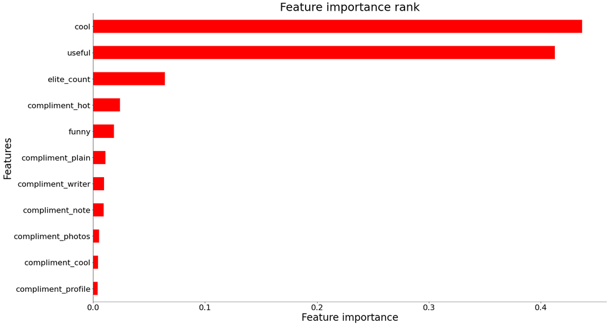

```python
%%local
ind = features.set_index("atribute", inplace = True)
barh = features.plot(kind='barh',figsize=(26, 15), color = "red", legend = None)
barh
plt.yticks(fontsize = 22)
plt.xticks(ind,fontsize = 22)
plt.xlabel("Feature importance", fontsize = 28)
plt.ylabel("Features", fontsize = 28)
plt.title("Feature importance rank", fontsize=32)
barh.spines['top'].set_visible(False)
barh.spines['right'].set_visible(False)
barh.spines['bottom'].set_linewidth(0.5)
barh.spines['left'].set_visible(True)
plt.show()
```

## Ejercicio 2: Identificando la probabilidad de cierre de un servicio

Desde Yelp están interesados en predecir la probabilidad de cierre de un servicio en base a los reviews y características de un negocio. Así, la primera iteración del modelo es generar una identificación de qué factores están asociados al cierre.

El equipo de desarrollo de Yelp le hace entrega de un archivo llamado recoding_business_schema.py que describe:

- Atributos a recodificar
- Atributos a mantener

Este archivo sirve como guía y no implementa la recodificación en el `pyspark.sql.dataframe.DataFrame`, esto es tarea de usted.

De manera adicional, cabe destacar que éste archivo no incluye la recodificación del vector objetivo ( `is_open`).

Usted deberá recodificarla de manera tal de identificar como 1 aquellos servicios que cerraron y 0 el resto.

```python
business = spark.read.json('s3://bigdata-desafio/yelp-data/business.json')
business.printSchema()
```

```
root
 |-- address: string (nullable = true)
 |-- attributes: struct (nullable = true)
 |    |-- AcceptsInsurance: string (nullable = true)
 |    |-- AgesAllowed: string (nullable = true)
 |    |-- Alcohol: string (nullable = true)
 |    |-- Ambience: string (nullable = true)
 |    |-- BYOB: string (nullable = true)
 |    |-- BYOBCorkage: string (nullable = true)
 |    |-- BestNights: string (nullable = true)
 |    |-- BikeParking: string (nullable = true)
 |    |-- BusinessAcceptsBitcoin: string (nullable = true)
 |    |-- BusinessAcceptsCreditCards: string (nullable = true)
 |    |-- BusinessParking: string (nullable = true)
 |    |-- ByAppointmentOnly: string (nullable = true)
 |    |-- Caters: string (nullable = true)
 |    |-- CoatCheck: string (nullable = true)
 |    |-- Corkage: string (nullable = true)
 |    |-- DietaryRestrictions: string (nullable = true)
 |    |-- DogsAllowed: string (nullable = true)
 |    |-- DriveThru: string (nullable = true)
 |    |-- GoodForDancing: string (nullable = true)
 |    |-- GoodForKids: string (nullable = true)
 |    |-- GoodForMeal: string (nullable = true)
 |    |-- HairSpecializesIn: string (nullable = true)
 |    |-- HappyHour: string (nullable = true)
 |    |-- HasTV: string (nullable = true)
 |    |-- Music: string (nullable = true)
 |    |-- NoiseLevel: string (nullable = true)
 |    |-- Open24Hours: string (nullable = true)
 |    |-- OutdoorSeating: string (nullable = true)
 |    |-- RestaurantsAttire: string (nullable = true)
 |    |-- RestaurantsCounterService: string (nullable = true)
 |    |-- RestaurantsDelivery: string (nullable = true)
 |    |-- RestaurantsGoodForGroups: string (nullable = true)
 |    |-- RestaurantsPriceRange2: string (nullable = true)
 |    |-- RestaurantsReservations: string (nullable = true)
 |    |-- RestaurantsTableService: string (nullable = true)
 |    |-- RestaurantsTakeOut: string (nullable = true)
 |    |-- Smoking: string (nullable = true)
 |    |-- WheelchairAccessible: string (nullable = true)
 |    |-- WiFi: string (nullable = true)
 |-- business_id: string (nullable = true)
 |-- categories: string (nullable = true)
 |-- city: string (nullable = true)
 |-- hours: struct (nullable = true)
 |    |-- Friday: string (nullable = true)
 |    |-- Monday: string (nullable = true)
 |    |-- Saturday: string (nullable = true)
 |    |-- Sunday: string (nullable = true)
 |    |-- Thursday: string (nullable = true)
 |    |-- Tuesday: string (nullable = true)
 |    |-- Wednesday: string (nullable = true)
 |-- is_open: long (nullable = true)
 |-- latitude: double (nullable = true)
 |-- longitude: double (nullable = true)
 |-- name: string (nullable = true)
 |-- postal_code: string (nullable = true)
 |-- review_count: long (nullable = true)
 |-- stars: double (nullable = true)
 |-- state: string (nullable = true)
```

```python
business.show(1)
```

```
+--------------------+--------------------+--------------------+-----------------+-------+-----+-------+----------+------------+--------------------+-----------+------------+-----+-----+
|             address|          attributes|         business_id|       categories|   city|hours|is_open|  latitude|   longitude|                name|postal_code|review_count|stars|state|
+--------------------+--------------------+--------------------+-----------------+-------+-----+-------+----------+------------+--------------------+-----------+------------+-----+-----+
|2818 E Camino Ace...|[,,,,,,,,,,,,,,,,...|1SWheh84yJXfytovI...|Golf, Active Life|Phoenix| null|      0|33.5221425|-112.0184807|Arizona Biltmore ...|      85016|           5|  3.0|   AZ|
+--------------------+--------------------+--------------------+-----------------+-------+-----+-------+----------+------------+--------------------+-----------+------------+-----+-----+
only showing top 1 row
```

```python
business.registerTempTable('business')
```

### Recodificación de variables

```python
business=business\
    .withColumn('accepts_insurance',
                when((col('attributes.AcceptsInsurance') == 'True')\
                     | (col('attributes.AcceptsInsurance') == "\'True\'")\
                     | (col('attributes.AcceptsInsurance') == "u\'True\'"), 1)\
                .otherwise(0).alias('insurance'))

# 1 if business is age-restricted, 0 otherwise
business=business\
    .withColumn('all_ages_allowed',
        when((col('attributes.AgesAllowed') == 'allages')\
            | (col('attributes.AgesAllowed') == "\'allages\'")\
            | (col('attributes.AgesAllowed') == "u\'allages\'"), 1)\
        .otherwise(0).alias('all_ages_allowed'))

# 1 if business allows alcohol consumption, 0 otherwise
business=business\
    .withColumn('alcohol_consumption',
        when((col('attributes.Alcohol') == 'beer_and_wine')\
             | (col('attributes.Alcohol') == "\'beer_and_wine\'")\
             | (col('attributes.Alcohol') == "u\'beer_and_wine\'")\
             | (col('attributes.Alcohol') == 'full_bar')\
             | (col('attributes.Alcohol') == "\'full_bar\'")\
             | (col('attributes.Alcohol') == "u\'full_bar\'"), 1)\
        .otherwise(0).alias('alcohol_consumption'))

# 1 if business accepts bitcoin as payment method, 0 otherwise
business=business\
    .withColumn('bitcoin_friendly',
        when((col('attributes.BusinessAcceptsBitcoin') == 'True')\
             | (col('attributes.BusinessAcceptsBitcoin') == True)\
             | (col('attributes.BusinessAcceptsBitcoin') == "\'True\'")\
             | (col('attributes.BusinessAcceptsBitcoin') == "u\'True\'"), 1)\
        .otherwise(0).alias('bitcoin_friendly'))

# 1 if business is food related, 0 otherwise
business=business\
    .withColumn('food_related',
        when((col('categories').rlike('Food'))\
             | (col('categories').rlike('Restaurants'))\
             | (col('categories').rlike('Bars')), 1)\
        .otherwise(0).alias('food_business'))

# 1 if business is finance related, 0 otherwise
business=business\
    .withColumn('finance_related', when(
        (col('categories').rlike('Banks'))\
         | (col('categories').rlike('Insurance'))\
         | (col('categories').rlike('Finance')), 1)\
        .otherwise(0).alias('finance_business'))

# 1 if business is health related, 0 otherwise
business=business\
    .withColumn('health_related', when(
        (col('categories').rlike('Fitness'))\
        | (col('categories').rlike('Hospitals'))\
        | (col('categories').rlike('Health')), 1)\
            .otherwise(0).alias('health_business'))

# 1 if business allows smoking, 0 otherwise
business=business\
    .withColumn('smoking', when((col('attributes.Smoking') == '\'yes\'')\
                 |(col('attributes.Smoking') == 'u\'yes\'')\
                 |(col('attributes.Smoking') == 'yes')\
                 |(col('attributes.Smoking') == '\'outdoor\'')\
                 |(col('attributes.Smoking') == 'u\'outdoor\'')\
                 |(col('attributes.Smoking') == 'outdoor'), 1)\
           .otherwise(0).alias('smokers'))

# 1 if business offers free wifi to its customers, 0 otherwise
business=business\
    .withColumn('free_wifi', when((col('attributes.WiFi') == '\'free\'')\
                | (col('attributes.WiFi') == 'u\'free\'')\
                | (col('attributes.WiFi') == 'free'), 1)\
           .otherwise(0).alias('free_wifi'))

# 1 if business can be considered expensive, 0 otherwise (applies only to restaurants)
business=business\
    .withColumn('expensive_restaurant', when((col('attributes.RestaurantsPriceRange2') == 3)\
                 | (col('attributes.RestaurantsPriceRange2') == 4), 1)\
            .otherwise(0).alias('splurge'))

# 1 if business is kid friendly, 0 otherwise
business=business\
    .withColumn('kid_friendly', when((col('attributes.GoodForKids') == 'True')\
                 | (col('attributes.GoodForKids') == True)\
                 | (col('attributes.GoodForKids') == "\'True\'")\
                 | (col('attributes.GoodForKids') == "u\'True\'"), 1)\
            .otherwise(0).alias('kids_friendly'))

# 1 if business has tv, 0 otherwise
business=business\
    .withColumn('has_tv', when((col('attributes.HasTV') == 'True')\
                 | (col('attributes.HasTV') == True)\
                 | (col('attributes.HasTV') == "\'True\'")\
                 | (col('attributes.HasTV') == "u\'True\'"), 1)\
            .otherwise(0).alias('has_tv'))

# 1 if business is dog friendly, 0 otherwise
business=business\
    .withColumn('dog_friendly', when((col('attributes.DogsAllowed') == 'True')\
                 | (col('attributes.DogsAllowed') == True)\
                 | (col('attributes.DogsAllowed') == "\True'\'")\
                 | (col('attributes.DogsAllowed') == "u\'True\'"), 1)\
            .otherwise(0).alias('dogs_friendly'))

# 1 if business can be considered as loud or very loud, 0 otherwise
business=business\
    .withColumn('loud_place', when((col('attributes.NoiseLevel') == 'loud')\
                 | (col('attributes.NoiseLevel') == "\'loud\'")\
                 | (col('attributes.NoiseLevel') == "u\'loud\'")\
                 | (col('attributes.NoiseLevel') == "very_loud")\
                 | (col('attributes.NoiseLevel') == "\'very_loud\'")\
                 | (col('attributes.NoiseLevel') == "u\'very_loud\'"), 1)\
            .otherwise(0).alias('loud_place'))

# 1 if business offers happy hours, 0 otherwise (applies only to restaurants)
business=business\
    .withColumn('happy_hour', when((col('attributes.HappyHour') == 'True')\
                 | (col('attributes.HappyHour') == True)\
                 | (col('attributes.HappyHour') == "\'True\'")\
                 | (col('attributes.HappyHour') == "u\'True\'"), 1)\
            .otherwise(0).alias('happy_hour'))
```

```python
business = business.select('is_open', 'review_count', 'stars', 'accepts_insurance',
'all_ages_allowed', 'alcohol_consumption', 'bitcoin_friendly', 'food_related',
'finance_related', 'health_related','smoking','free_wifi','has_tv',
'dog_friendly','kid_friendly','expensive_restaurant','loud_place','happy_hour')
```

```python
business.columns
```

```
['is_open', 'review_count', 'stars', 'accepts_insurance', 'all_ages_allowed', 'alcohol_consumption', 'bitcoin_friendly', 'food_related', 'finance_related', 'health_related', 'smoking', 'free_wifi', 'has_tv', 'dog_friendly', 'kid_friendly', 'expensive_restaurant', 'loud_place', 'happy_hour']
```

```python
business.take(2)
```

```
[Row(is_open=0, review_count=5, stars=3.0, accepts_insurance=0, all_ages_allowed=0, alcohol_consumption=0, bitcoin_friendly=0, food_related=0, finance_related=0, health_related=0, smoking=0, free_wifi=0, has_tv=0, dog_friendly=0, kid_friendly=0, expensive_restaurant=0, loud_place=0, happy_hour=0), R…
```

### Revisión de datos perdidos

```python
business.count()
```

```
192609
```

```python
business.select([count(when(isnull(c), c)).alias(c) for c in business.columns]).toPandas().T
```

```
                      0
is_open               0
review_count          0
stars                 0
accepts_insurance     0
all_ages_allowed      0
alcohol_consumption   0
bitcoin_friendly      0
food_related          0
finance_related       0
health_related        0
smoking               0
free_wifi             0
has_tv                0
dog_friendly          0
kid_friendly          0
expensive_restaurant  0
loud_place            0
happy_hour            0
```

### Recodificación vector objetivo

```python
business = business.withColumnRenamed("is_open", "label")
business = business\
    .withColumn('label', when(business['label'] == 0, 1)\
    .otherwise(0))
```

```python
business.take(1)
```

```
[Row(label=1, review_count=5, stars=3.0, accepts_insurance=0, all_ages_allowed=0, alcohol_consumption=0, bitcoin_friendly=0, food_related=0, finance_related=0, health_related=0, smoking=0, free_wifi=0, has_tv=0, dog_friendly=0, kid_friendly=0, expensive_restaurant=0, loud_place=0, happy_hour=0)]
```

```python
business.groupBy('label').count().sort('count',ascending= False).show()
```

```
+-----+------+
|label| count|
+-----+------+
|    0|158525|
|    1| 34084|
+-----+------+
```

Existen 34.084 servicios que han cerrado, es decir, un 18% de ellos

### Visualización datos preprocesados

```python
business.registerTempTable('business')
```

```python
%%sql -o business
SELECT * FROM business
```

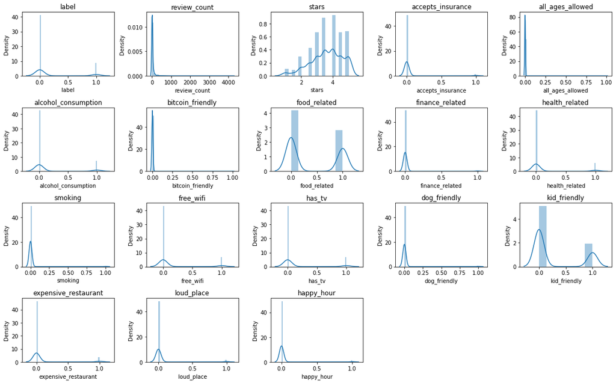

```python
%%local
rows = 4
cols = np.ceil(len(business.columns) / rows)
plt.rcParams['figure.figsize'] = (16, 10)
for index, (colname, serie) in enumerate(business.iteritems()):
    plt.subplot(rows, cols, index + 1)
    if serie.dtype == 'object':
        sns.countplot(serie);
    else:
        sns.distplot(serie)
    plt.title(colname);
    plt.tight_layout()
```

### Modelamiento

```python
feats = business.columns
feats.remove('label')
```

```python
assemble_feats = VectorAssembler(inputCols = feats, outputCol = 'assembled_features')
assemble_feats = assemble_feats.transform(business)
assemble_feats = assemble_feats.select(['label', 'assembled_features'])
```

```python
train, test = assemble_feats.randomSplit([0.7, 0.3], seed = 1234)
```

#### Logistic Regression

```python
lrModel = LogisticRegression(featuresCol = 'assembled_features', labelCol = 'label', maxIter=10).fit(train)
predict_lr = lrModel.transform(test)
metric_lr = lrModel.evaluate(test).areaUnderROC
```

#### GBTClassifier

```python
GBT = GBTClassifier(featuresCol='assembled_features', labelCol='label').fit(train)
predict_GBT = GBT.transform(test)
evaluaGBT = BinaryClassificationEvaluator()
metric_GBT = evaluaGBT.evaluate(predict_GBT, {evaluaGBT.metricName : "areaUnderROC"})
```

#### DecisionTreeClassifier

```python
DTreeC = DecisionTreeClassifier(featuresCol='assembled_features', labelCol='label').fit(train)
predict_DTreeC = DTreeC.transform(test)
evaluaDT = BinaryClassificationEvaluator()
metric_DTreeC = evaluaDT.evaluate(predict_DTreeC, {evaluaDT.metricName : "areaUnderROC"})
```

```python
print('El AUC de LogisticRegression es {}.'.format(round(metric_lr,5)))
print('El AUC de GBTClassifier es {}.'.format(round(metric_GBT,5)))
print('El AUC de DecisionTreeClassifier es {}.'.format(round(metric_DTreeC,5)))
```

```
El AUC de LogisticRegression es 0.69238.
El AUC de GBTClassifier es 0.70625.
El AUC de DecisionTreeClassifier es 0.35985.
```

El mejor modelo según su AUC es el GBTClassifier

### Principales atributos

```python
feat_importance = pd.DataFrame({'col':feats, 'importance': GBT.featureImportances.toArray()})
sdf = sqlContext.createDataFrame(feat_importance)
sdf.select("*").show()
sdf.registerTempTable('features')
```

```
+--------------------+--------------------+
|                 col|          importance|
+--------------------+--------------------+
|        review_count| 0.22289911282709846|
|               stars|  0.1846557998668425|
|   accepts_insurance| 0.07643544386529327|
|    all_ages_allowed|0.001329804290227...|
| alcohol_consumption| 0.07960802244654336|
|    bitcoin_friendly|0.001504931231286...|
|        food_related| 0.16457589023997307|
|     finance_related|0.026339634091840525|
|      health_related| 0.01587825526882481|
|             smoking|0.010072505844215613|
|           free_wifi|0.016220743371682896|
|              has_tv|0.031860826676057184|
|        dog_friendly|0.003926839566382...|
|        kid_friendly| 0.06987617476616068|
|expensive_restaurant| 0.03917820747435459|
|          loud_place|0.015666135439535413|
|          happy_hour| 0.03997167273368171|
+--------------------+--------------------+
```

```python
%%sql -o features
SELECT col AS atribute, importance FROM features ORDER BY importance asc
```

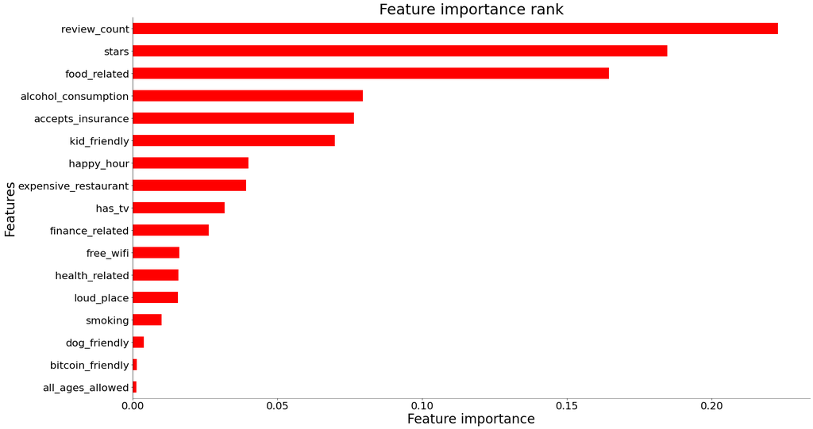

```python
%%local
ind = features.set_index("atribute", inplace = True)
barh = features.plot(kind='barh',figsize=(26, 15), color = "red", legend = None)
barh
plt.yticks(fontsize = 22)
plt.xticks(ind,fontsize = 22)
plt.xlabel("Feature importance", fontsize = 28)
plt.ylabel("Features", fontsize = 28)
plt.title("Feature importance rank", fontsize=32)
barh.spines['top'].set_visible(False)
barh.spines['right'].set_visible(False)
barh.spines['bottom'].set_linewidth(0.5)
barh.spines['left'].set_visible(True)
plt.show()
```

### Conclusiones

Naturalmente, el AUC pudo entregar un mayor desempeño por el ensamble bajo el cual se construye, a priori, asumiría que las variables están correlacionadas entre sí, sin embargo, son independientes y no colineales, por lo que su peso relativo dentro del modelo podrían influir más en la predicción, a diferencia del caso anterior.

Viendo los features, intentaría poner como base aquellos que sean mayor igual a 5% dentro del modelo, aunque aun así, es un criterio laxo, dado que, para predecir el cierre de servicios, podría ser explicado por las 5-10 razones (atributos) más importantes

El muy bajo AUC del árbol, podría estar explicado porque no se hace cargo de los desbalanceos de las muestras, haciendo que sus resultados sean poco estables.